# PROYECTO

```r
library(readr)
library(tidyverse)
library(ggpmisc)
library(ggpubr)
library("survival")
library("fitdistrplus")
BC<- read_csv("heart.csv")
```

# Características predominantes en la predicción de insuficiencia cardíaca

## 1. Introducción:

Las enfermedades cardiovasculares (ECV) son la principal causa de muerte en todo el mundo y se cobran aproximadamente 17,9 millones de vidas cada año, lo que representa el 31 % de todas las muertes en todo el mundo. Cuatro de cada 5 muertes por ECV se deben a ataques cardíacos y accidentes cerebrovasculares, y un tercio de estas muertes ocurren prematuramente en personas menores de 70 años. La insuficiencia cardíaca es un evento común causado por ECV y este conjunto de datos contiene 9 características que pueden usarse para predecir una posible enfermedad cardíaca.

**Trabajos similares:**

Vega determinó que la predicción del riesgo cardiovascular resulta ser una herramienta útil del médico para establecer prioridades en la atención primaria, mejorando la atención a los pacientes y eligiendo más eficazmente la terapéutica a seguir. Le permite plantear objetivos más cercanos a la realidad multifactorial de las enfermedades cardiovasculares y a su prevención. En este sentido, mejorar la exactitud en la predicción del riesgo requiere la evaluación y el tratamiento de múltiples factores de riesgo cardiovascular, los que tienen un efecto sinérgico, más que aditivo, sobre el riesgo cardiovascular total. [Jorge Vega, 2011]

Díez encontró en su estudio que la prevalencia de las enfermedades cardiovasculares y sus factores de riesgo en atención primaria eran determinantes para la aparición de enfermedades cardiovasculares son especialmente frecuentes en varones y ancianos, asimismo que el 57,9% presentó al menos 1 factor de riesgo. Por otro lado que la edad media fue de 49,1 ± 18,9 años. [Baena Díez, J. M., 2005]

Fernández obtuvo que una de cada diez personas sufre de enfermedad cardiovascular. Por otro lado, los factores que contribuyen a la aparición de ECV son: sexo masculino, edad (de 50 años en adelante), inactividad física o exceso de ésta, estado de viudedad, nivel de estudios primario, clase social no cualificada, padecer sobrepeso/obesidad, HTA, colesterol y diabetes. Donde se concluyó que los factores de riesgo que más influyen en la enfermedad cardiovascular son, edad mayor de 65 años, sedentarismo, padecer HTA, diabetes y/o colesterol. [Pérez Fernández, 2017]

Es por esta razón que el grupo se dispuso a analizar los 5 datasets obtenidos del hospital Universitario(Zurich-Suiza), Hospital Universitario(Basilea-Suiza) y del Medical Center Fundación de Long Beach y Cleveland Clinic Robert Detrano, MD, Ph.D. del instituto Húngaro de Cardiología Budapest quienes realizaron una toma de datos a sus pacientes con sospecha de Insuficiencia Cardíaca.

*Pregunta General:*

¿Cuáles son las principales características en la predicción de insuficiencia cardíaca?

**1.1 Relevancia:**

Se sabe que más del 30% de las muertes anuales son causadas por enfermedades cardíacas, por ello, nuestro grupo busca un análisis descriptivo de 12 variables referentes a las enfermedades cardiovasculares. Asimismo, involucra la aplicación de los conocimientos en R adquiridos durante el curso con el fin de determinar relaciones entre variables que sean relevantes y que demuestren una señal de alerta **1.2 Planificación:**

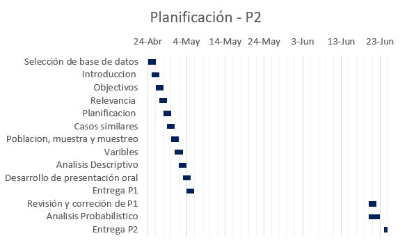

## 2. Datos

**2.1 Proceso de Recolección de Datos:**

Se trabajó con un dataset publicado en Kaggle donde sus creadores Andras Janosi, William Steinbrunn, Matthias Pfisterer y Robert Detrano combinaron datasets ya existentes mediante 11 características comunes.

**2.2 Población Muestra y Muestreo:**

Para la realización de este dataset se consideró información de 5 datasets los cuales son Cleveland: 303 observations, Hungarian: 294 observations, Switzerland: 123 observations, Long Beach VA: 200 observations y Stalog (Heart) Data Set: 270 observations. Resultando un dataset completo de 918 observaciones y 12 variables. Sin embargo, para la realización de este proyecto se descartaron 3 variables: Oldpeak, ST_Slope y Colesterol, trabajando únicamente con 918 observaciones y 9 variables.

**2.3 Variables:**

*Edad:* Numérica discreta, números positivos enteros a partir de 1 en años.

*Sexo:* Categórico nominal, femenino o masculino.

*Tipo* de dolor de pecho: Categórico nominal.

- Angina típica(TA): Es el dolor de pecho a causa de la débil circulación de la sangre.
- Angina atípica(ATA.): Es el dolor de pecho molesto que genera estrés emocional.
- Dolor no Anginoso(NAP,): Es el dolor de pecho normal no implica problemas fisiológico.
- Asintomático(ASY): No tiene ningún síntoma de la Angina

*Presión arterial en reposo:* Numérico continua, número entero positivo a partir de 0 en mm Hg.

*Electrocardiograma:* Categórica nominal.

- Normal.-N o presenta anomalías en las ondas.
- ST(con anomalías en la ondas ST-T )
- LVH(que muestra hipertrofia ventricular izquierda probable o definitiva según los criterios.

*Frecuencia cardíaca máxima:* Numérica continua, número entero positivo de 60 hasta 202.

*Angina inducida por ejercicio:* Categórica nominal, Y(si), N(no).

*Enfermedad del corazón:* Categórica nominal, 1(Enfermedad de corazón) o 0(normal)

**2.4 Unidad de analisis**

[figure not shown]

Unidad de analisis

**2.4 Limpieza de base de datos**

Los datos han sido extraídos de Kaggle. El dataset no presenta datos faltantes, es decir, ya se encuentra limpia.

```r
sum(is.na(BC))
```

```
## [1] 0
```

```r
sum(!is.na(BC))
```

```
## [1] 11016
```

```r
sum(!complete.cases(BC))
```

```
## [1] 0
```

```r
sum(complete.cases(BC))
```

```
## [1] 918
```

```r
#Total de faltantes
sum(is.na(BC))
```

```
## [1] 0
```

```r
#% Faltantes
round(sum(is.na(BC))*100/prod(dim(BC)),2)
```

```
## [1] 0
```

## 3. Objetivos:

**3.1 General:** Determinar los principales factores que determinan presentar o no una enfermedad cardiaca

- Determinar el rango de edad más común dentro de la data analizando la variable edad de los 5 dataset.
- Determinar el sexo que predomina en la data mediando el análisis de la variable sexo de los 5 dataset y la relación entre el sexo y la detección de enfermedades cardíacas
- Determinar la relación entre edad y detección de enfermedad cardíaca
- Determinar cuál es el dolor más común dentro de los pacientes haciendo uso de la variable tipos de dolor en el pecho de los 5 dataset.
- Demostrar si determinante el ritmo cardíaco con la edad para contraer suficiencia cardiaca
- Determinar la influencia de la edad en el dolor de pecho

## 4. Analisis descriptivo:

- **Edad:**

La gráfica nos muestra que la edad de la mayoría de pacientes esta entre 47 - 60 años. No contiene valores atípico y tiene una desviación estándar 9.4. Por tal motivo, la desviación de esta variable es mínima y nos permite trabajar con valores centrados similares, como lo son su media y mediana.

Minimo:

```r
min(BC$Edad)
```

```
## [1] 28
```

Maximo:

```r
max(BC$Edad)
```

```
## [1] 77
```

Promedio:

```r
mean(BC$Edad)
```

```
## [1] 53.51089
```

Mediana:

```r
median(BC$Edad)
```

```
## [1] 54
```

Desviacion estandar:

```r
round(sd(BC$Edad), digits = 2)
```

```
## [1] 9.43
```

- **Sexo:**
  - cantidad de varones : 725(78.98%)
  - cantidad de mujeres: 193(21.02%)

```r
table(BC$Sexo)
```

```
##
##   F   M
## 193 725
```

```r
round(table(BC$Sexo)/nrow(BC)*100, digits = 2)
```

```
##
##     F     M
## 21.02 78.98
```

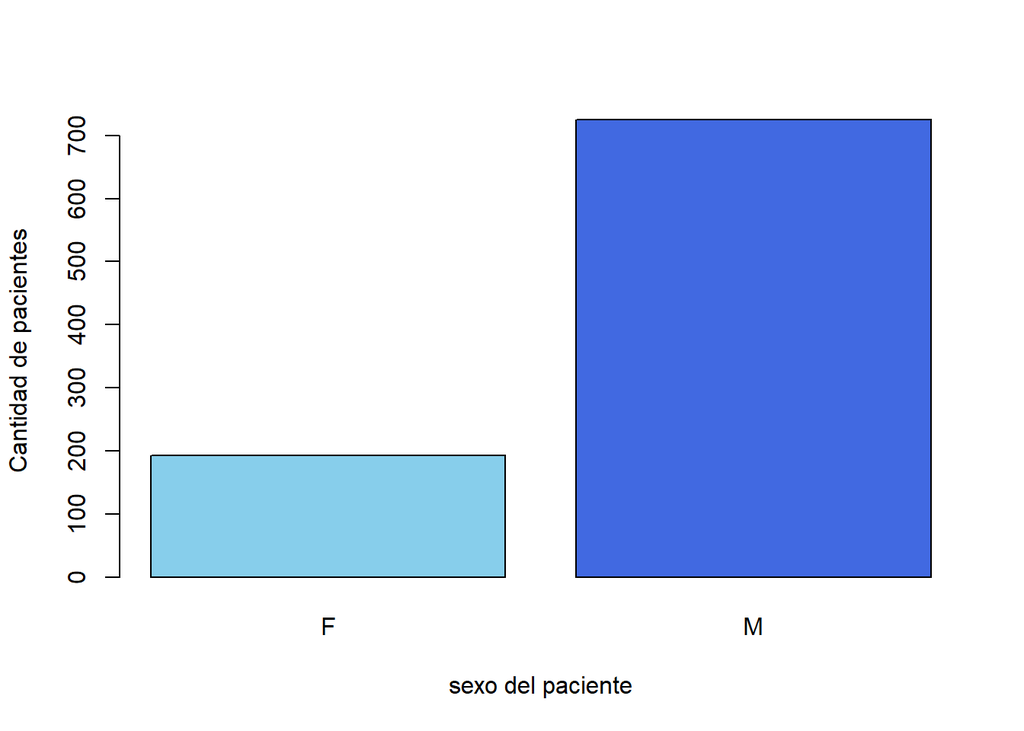

```r
barplot(table(BC$Sexo),xlab = "sexo del paciente",ylab = "Cantidad de pacientes",col = c("skyblue","royalblue" ))
```

- **Tipo de dolor:**

```r
table(BC$TipoDeDolorDePecho)
```

```
##
## ASY ATA NAP  TA
## 496 173 203  46
```

```r
round(table(BC$TipoDeDolorDePecho)/nrow(BC)*100, digits = 2)
```

```
##
##   ASY   ATA   NAP    TA
## 54.03 18.85 22.11  5.01
```

- Cantidad de personas con dolor ASY:496(54.03%)
- Cantidad de personas con dolor ATA:173(18.85%)
- Cantidad de personas con dolor NAP:203(22.11%)
- Cantidad de personas con dolor TA:46(5.01%)

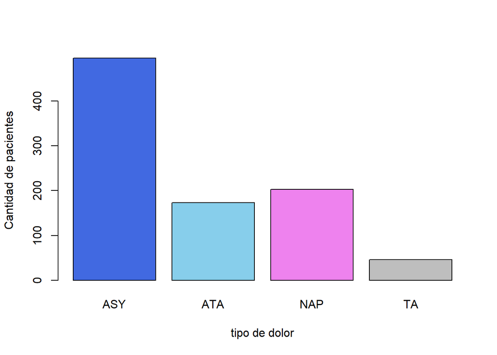

```r
barplot(table(BC$TipoDeDolorDePecho),xlab = "tipo de dolor",ylab = "Cantidad de pacientes",col = c("royalblue", "skyblue", "violet", "grey"))
```

- **Presión Arterial en Reposo:** En el gráfico se puede observar que existen datos de 0. Lo cual es imposible por lo cual se toma como dato atipico. Entonces, definimos que los descriptores numéricos de esta variable nos permite trabajar usando tanto la media como la mediana, retirando los datos atípicos.

Minimo:

```r
min(BC$PresionArterialEnReposo)
```

```
## [1] 0
```

Maximo:

```r
max(BC$PresionArterialEnReposo)
```

```
## [1] 200
```

Promedio:

```r
mean(BC$PresionArterialEnReposo)
```

```
## [1] 132.3965
```

Mediana:

```r
median(BC$PresionArterialEnReposo)
```

```
## [1] 130
```

-**Resultados de electrocardiograma en Reposo:**

- Cantidad de persona que muestra hipertrofia ventricular izquierda(LVH):188(20.48%)
- Cantidad de persona que no presenta anomalías en las ondas(Normal):552(60.13%)
- Cantidad de persona que presenta anomalías en las ondas(ST):178(19.39%)

```r
table(BC$ResultadosDelElectrocardiogramaEnReposo)
```

```
##
##    LVH Normal     ST
##    188    552    178
```

```r
round(table(BC$ResultadosDelElectrocardiogramaEnReposo)/nrow(BC)*100, digits = 2)
```

```
##
##    LVH Normal     ST
##  20.48  60.13  19.39
```

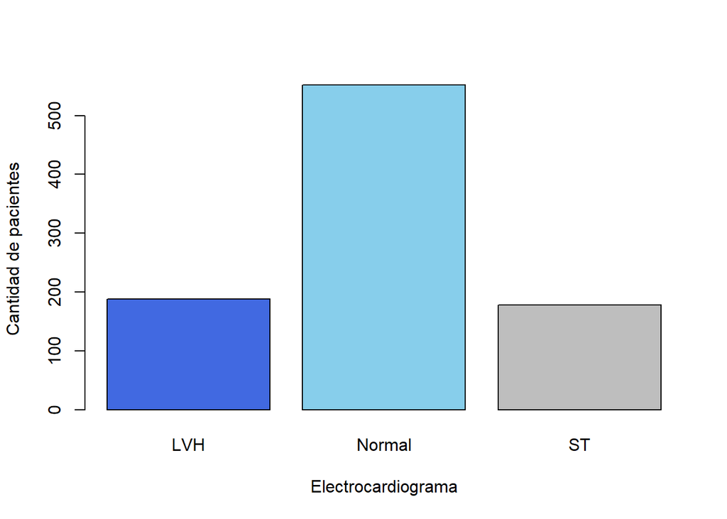

```r
barplot(table(BC$ResultadosDelElectrocardiogramaEnReposo),xlab = "Electrocardiograma",ylab = "Cantidad de pacientes",col = c("royalblue", "skyblue", "grey"))
```

Minino:

```r
min(BC$FrecuenciaCardiacaMaximaAlcanzada)
```

```
## [1] 60
```

Maximo:

```r
max(BC$FrecuenciaCardiacaMaximaAlcanzada)
```

```
## [1] 202
```

Promedio:

```r
mean(BC$FrecuenciaCardiacaMaximaAlcanzada)
```

```
## [1] 136.8094
```

Mediana:

```r
median(BC$FrecuenciaCardiacaMaximaAlcanzada)
```

```
## [1] 138
```

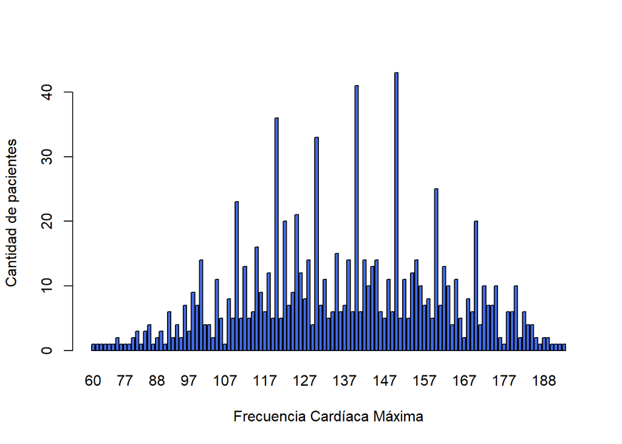

```r
barplot(table(BC$FrecuenciaCardiacaMaximaAlcanzada),xlab = "Frecuencia Cardíaca Máxima",ylab = "Cantidad de pacientes",col = c("royalblue" ))
```

- **Angina o dolor inducido por ejercicios:**
  - Cantidad de personas que presentan dolor por ejercicios: 371(40.41)
    - Cantidad de personas que no presentan dolor por ejercicios: 547(59.59)

```r
table(BC$AnginaInducidaPorEjercicio) - round(table(BC$AnginaInducidaPorEjercicio)/nrow(BC)*100, digits = 2)
```

```
##
##      N      Y
## 487.41 330.59
```

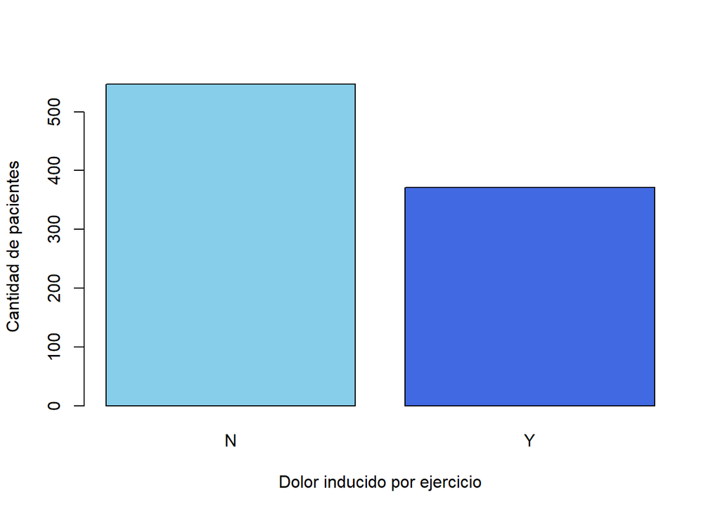

```r
barplot(table(BC$AnginaInducidaPorEjercicio),xlab = "Dolor inducido por ejercicio",ylab = "Cantidad de pacientes",col = c("skyblue","royalblue" ))
```

```r
table(BC$EnfermedadCardiaca) - round(table(BC$EnfermedadCardiaca)/nrow(BC)*100, digits = 2)
```

```
##
##      0      1
## 365.34 452.66
```

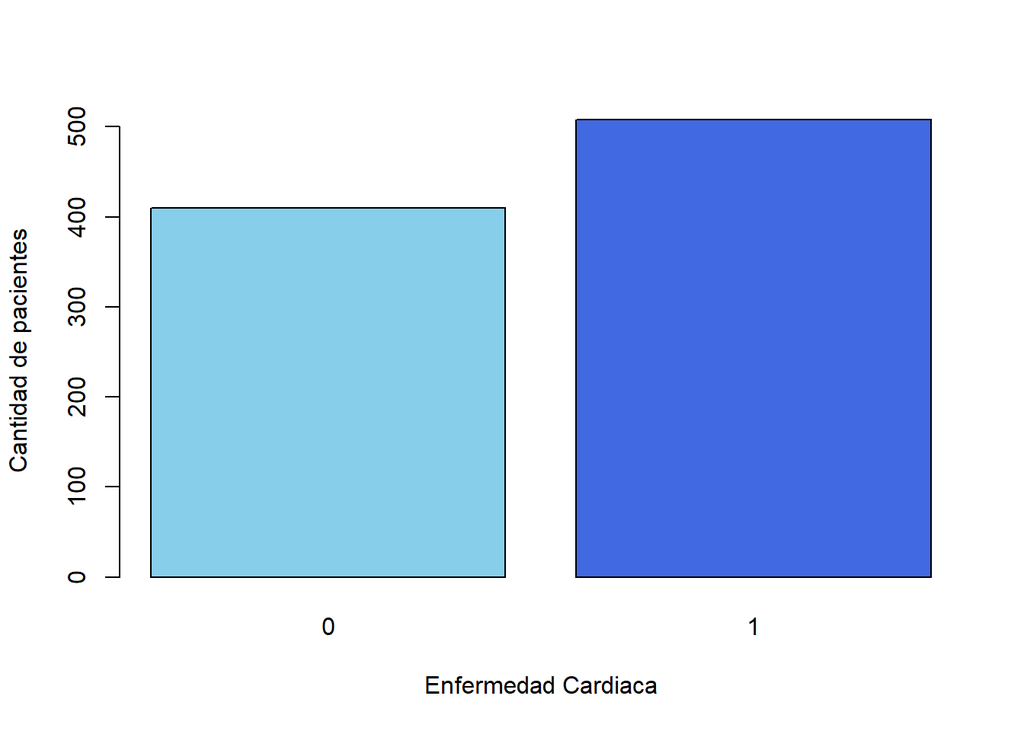

```r
barplot(table(BC$EnfermedadCardiaca),xlab = "Enfermedad Cardiaca",ylab = "Cantidad de pacientes",col = c("skyblue","royalblue" ))
```

## Sustentación de objetivos especfícos:

- Determinar el rango de edad más común dentro de la data analizando la variable edad de los 5 dataset.

  Con ayuda de la función summary(), obtenemos los valores máximos y mínimos correspondientes de la variable ‘Edad’. Con ello, determinamos que el rango en nuestra base de datos para la variable ‘Edad’ va de 28-77 años. Mientras, nos apoyamos de su barplot y gráfico de dispersión para determinar que el rango más común de la variable es de aproximadamente 41-65 años.

```r
summary(BC$Edad)
```

```
##    Min. 1st Qu.  Median    Mean 3rd Qu.    Max.
##   28.00   47.00   54.00   53.51   60.00   77.00
```

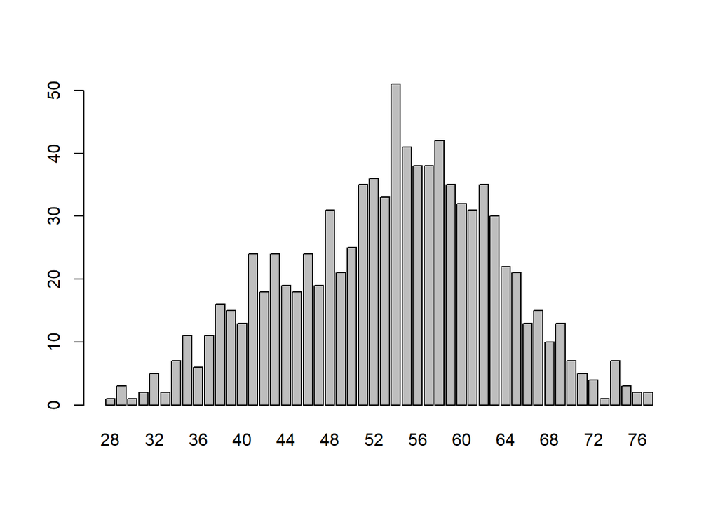

```r
barplot(table(BC$Edad))
```

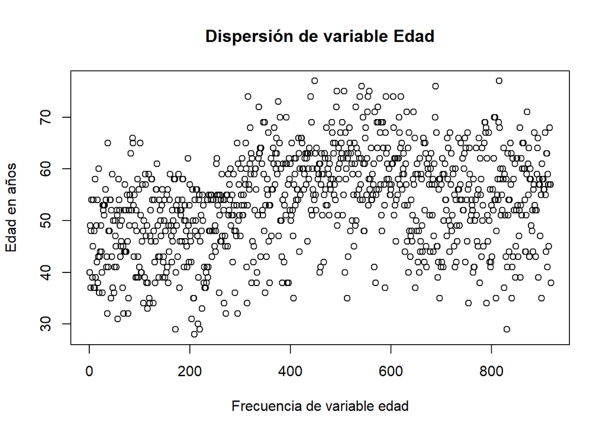

```r
plot(BC$Edad, main = "Dispersión de variable Edad",
     xlab = "Frecuencia de variable edad",
     ylab = "Edad en años",
     ylim = c(28,77),
     xlim = c(0, 918))
```

- Determinar el sexo que predomina en la data mediando el análisis de la variable sexo de los 5 dataset y la relación entre el sexo y la diagnóstico de enfermedades cardíacas

El sexo que más predomina en nuestra base de datos es el sexo masculino con 78.98% sobre el total de observaciones. Además, al relacionar con la variable ‘Enfermedad cardíaca’, se ve una distinción entre la variable ‘Sexo’. A partir de acá, se evidencia en el gráfico que el sexo Masculino, denotado por M, tiene más detecciones de enfermedad cardíaca que el sexo Femenino, denotado por F. También se ha determinado los porcentajes:

```r
table(BC$EnfermedadCardiaca,BC$Sexo)
```

```
##
##       F   M
##   0 143 267
##   1  50 458
```

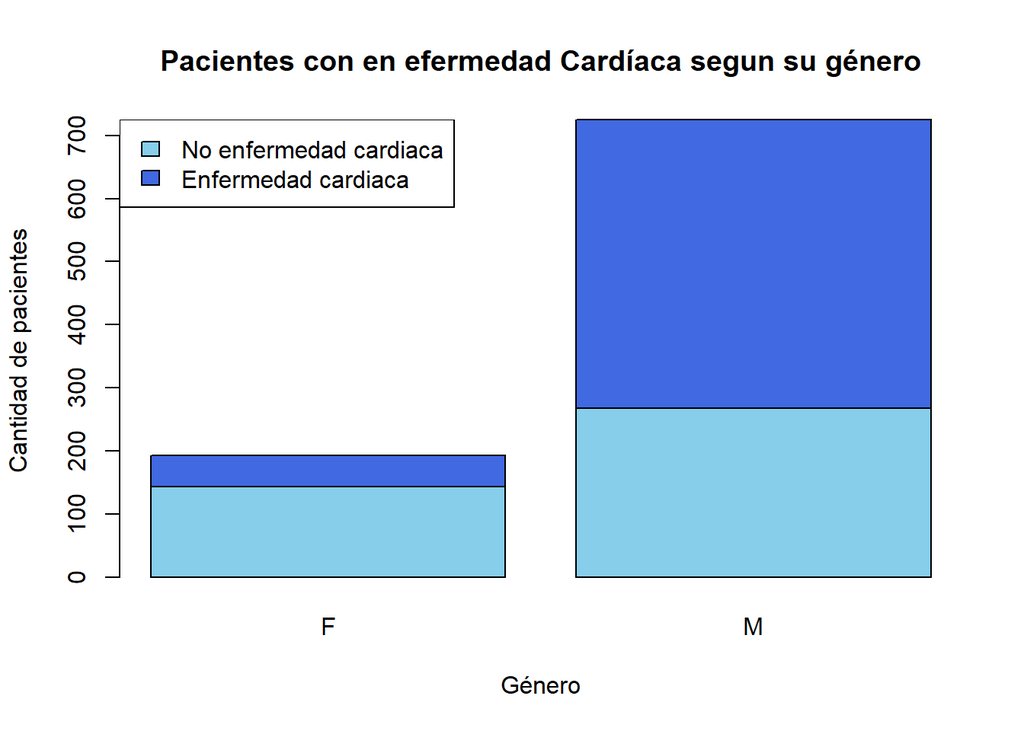

```r
barplot(table(BC$EnfermedadCardiaca,BC$Sexo),
main = "Pacientes con en efermedad Cardíaca segun su género",
xlab = "Género", ylab = "Cantidad de pacientes",
col = c("skyblue","royalblue")
)
legend("topleft",
c("No enfermedad cardiaca","Enfermedad cardiaca"),
fill = c("skyblue","royalblue")
)
```

```r
round(table(BC$EnfermedadCardiaca,BC$Sexo)/nrow(BC)*100, digits = 2)
```

```
##
##         F     M
##   0 15.58 29.08
##   1  5.45 49.89
```

- Determinar la relación entre la presion y la enfermedad cardíaca

[figure not shown]

```r
ggplot(BC, aes(x = EnfermedadCardiaca, y = PresionArterialEnReposo)) + geom_boxplot()
```

- Determinar la relación entre edad y diagnóstico de enfermedad cardíaca

Después de analizar las variables independientemente y su relación mediante la función image() y ggplot(), vemos que existe una alta frecuencia entre las edades 40-65 años que resultaron positivo (1) para enfermedades cardíacas. Por tanto, concluimos que existe un relación directa entre edad y enfermedades cardíacas.

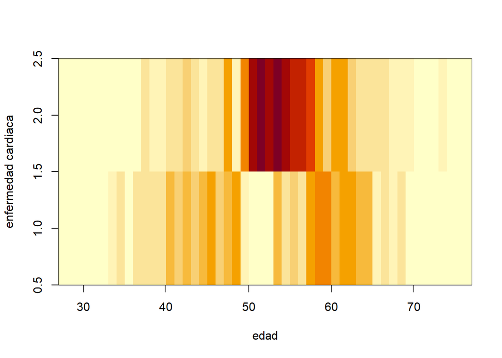

```r
library(ggplot2)

image(x = 27:77, y = 1:2,table(sort(BC$Edad), BC$EnfermedadCardiaca), xlab = "edad", ylab = "enfermedad cardiaca")
```

[figure not shown]

```r
ggplot(BC, aes(x = EnfermedadCardiaca, y = Edad)) + geom_boxplot()
```

- Determinar cuál es el dolor más común dentro de los pacientes haciendo uso de la variable tipos de dolor en el pecho de los 5 dataset.

Realizando un barplot con la variable ‘Tipo de dolor de pecho’, vemos la incidencia por pacientes. Por ello, vemos que 496 presentan ASY; 173, ATA; 203, NAP; 46, TA. Entonces, según la gráfica y los datos, los pacientes describen su sensación como ASY, que significa asintomático. Entonces, la mayoría de los pacientes son asíntomáticos para los dolores que manifiestan las enfermedades cardíacas.

```r
table(BC$TipoDeDolorDePecho)
```

```
##
## ASY ATA NAP  TA
## 496 173 203  46
```

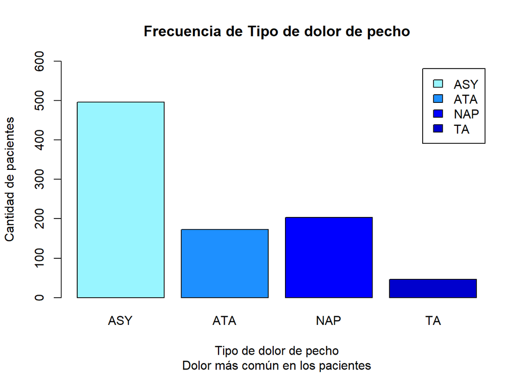

```r
barplot(table(BC$TipoDeDolorDePecho),
        main = "Frecuencia de Tipo de dolor de pecho",
        sub = "Dolor más común en los pacientes",
        xlab = "Tipo de dolor de pecho",
        ylab = "Cantidad de pacientes",
        ylim = c(0,600),
        col = c("cadetblue1", "dodgerblue1", "blue", "blue3"),
        legend.text = c("ASY", "ATA", "NAP", "TA"))
```

- Demostrar si determinante el ritmo cardíaco con la edad para contraer suficiencia cardiaca

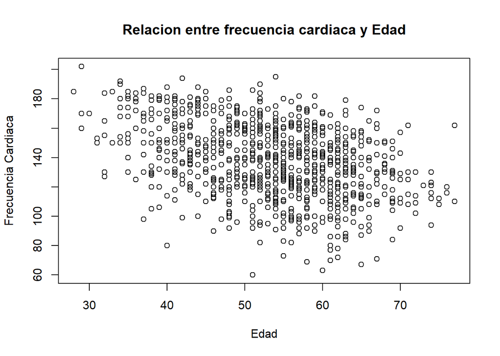

```r
plot(BC$Edad,BC$FrecuenciaCardiacaMaximaAlcanzada,
     ylab="Frecuencia Cardiaca",xlab="Edad",
     main = "Relacion entre frecuencia cardiaca y Edad")
```

- Determinar la relación entre la cantidad de pacientes y el tipo de angina

Hay una mayor probabilidad de presentar alguna enfermedad cardíaca si presentas (ASY) asintomáticas.

```r
table(BC$EnfermedadCardiaca,BC$TipoDeDolorDePecho)
```

```
##
##     ASY ATA NAP  TA
##   0 104 149 131  26
##   1 392  24  72  20
```

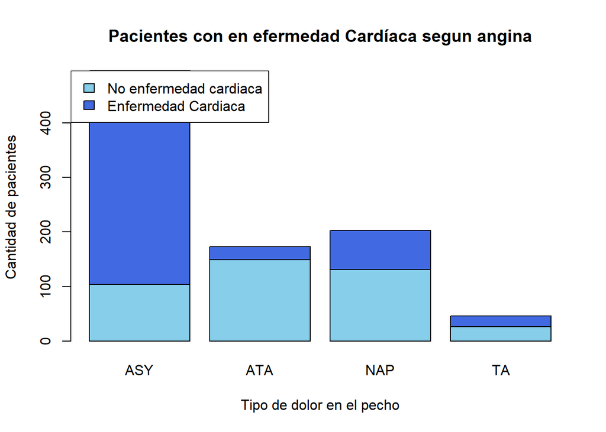

```r
barplot(table(BC$EnfermedadCardiaca,BC$TipoDeDolorDePecho),
main = "Pacientes con en efermedad Cardíaca segun angina",
xlab = "Tipo de dolor en el pecho", ylab = "Cantidad de pacientes",
col = c("skyblue","royalblue")
)
legend("topleft",
c("No enfermedad cardiaca","Enfermedad Cardiaca"),
fill = c("skyblue","royalblue")
)
```

- Determinar la influencia de la edad en el dolor de pecho

Según el boxplot realizado, se determina la relación de la edad por cada tipo de dolor de pecho que describen los pacientes.

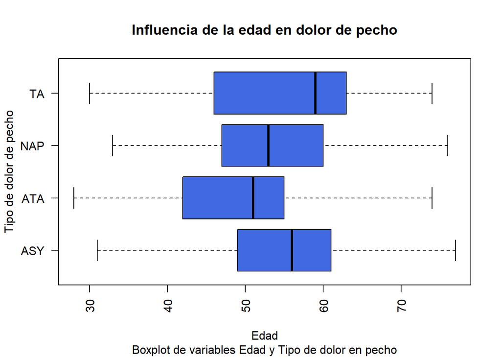

```r
boxplot(BC$Edad~BC$TipoDeDolorDePecho,
        main = "Influencia de la edad en dolor de pecho",
        sub = "Boxplot de variables Edad y Tipo de dolor en pecho",
        horizontal = TRUE,
        ylab = "Tipo de dolor de pecho",
        xlab = "Edad",
        col = c("royalblue"),
        las = 2,
        )
```

- Determinar relación entre diagnóstico de enfermedad cardíacada con la frecuencia máxima alcanzada.

```r
table(BC$EnfermedadCardiaca,BC$FrecuenciaCardiacaMaximaAlcanzada)
```

```
##
##     60 63 67 69 70 71 72 73 77 78 80 82 83 84 86 87 88 90 91 92 93 94 95 96 97
##   0  0  0  0  1  0  0  0  0  0  0  1  0  0  0  2  0  0  1  0  0  0  0  0  3  1
##   1  1  1  1  0  1  1  2  1  1  1  1  3  1  3  2  1  2  2  1  6  2  4  2  4  2
##
##     98 99 100 102 103 104 105 106 107 108 109 110 111 112 113 114 115 116 117
##   0  2  1   6   0   0   0   1   1   1   0   0   7   2   2   0   3   4   5   0
##   1  7  6   8   4   4   2  10   4   0   8   5  16   3  11   5   3  12   4   6
##
##     118 119 120 121 122 123 124 125 126 127 128 129 130 131 132 133 134 135 136
##   0   4   0  11   1   5   1   1   4   4   2   3   1  11   3   4   3   2   9   2
##   1   8   5  25   4  15   6   8  17   8   6  11   3  22   4   7   2   4   6   4
##
##     137 138 139 140 141 142 143 144 145 146 147 148 149 150 151 152 153 154 155
##   0   7   9   4  18   2   9   4   6   5   3   2   6   2  20   5   8   3   7   8
##   1   0   5   2  23   4   5   6   7   9   3   3   5   4  23   0   3   2   5   6
##
##     156 157 158 159 160 161 162 163 164 165 166 167 168 169 170 171 172 173 174
##   0   4   4   4   3  19   4   9   7   3   8   2   2   6   4  14   3  10   5   5
##   1   6   3   4   2   6   3   4   3   1   3   3   0   2   2   6   1   0   2   2
##
##     175 176 177 178 179 180 181 182 184 185 186 187 188 190 192 194 195 202
##   0   7   1   0   6   6   8   1   4   4   4   2   1   2   2   1   1   0   1
##   1   3   1   1   0   0   2   1   2   0   0   0   0   0   0   0   0   1   0
```

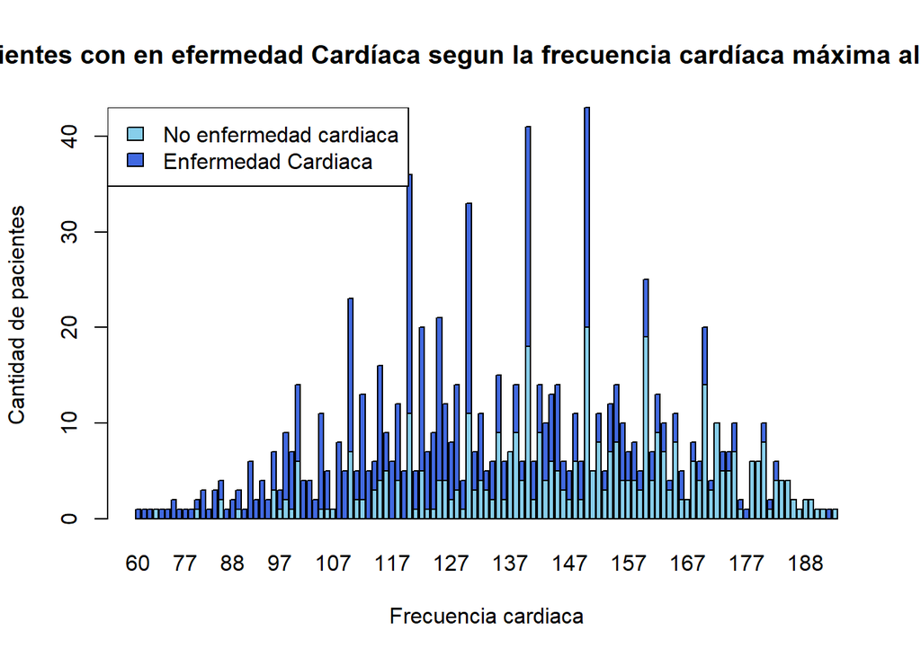

```r
barplot(table(BC$EnfermedadCardiaca,BC$FrecuenciaCardiacaMaximaAlcanzada),
main = "Pacientes con en efermedad Cardíaca segun la frecuencia cardíaca máxima alcanzada",
xlab = "Frecuencia cardiaca", ylab = "Cantidad de pacientes",
col = c("skyblue","royalblue")
)
legend("topleft",
c("No enfermedad cardiaca","Enfermedad Cardiaca"),
fill = c("skyblue","royalblue")
)
```

[figure not shown]

```r
ggplot(BC, aes(x = EnfermedadCardiaca, y = FrecuenciaCardiacaMaximaAlcanzada)) + geom_boxplot()
```

- Objetivo por el siguiente scatterplot

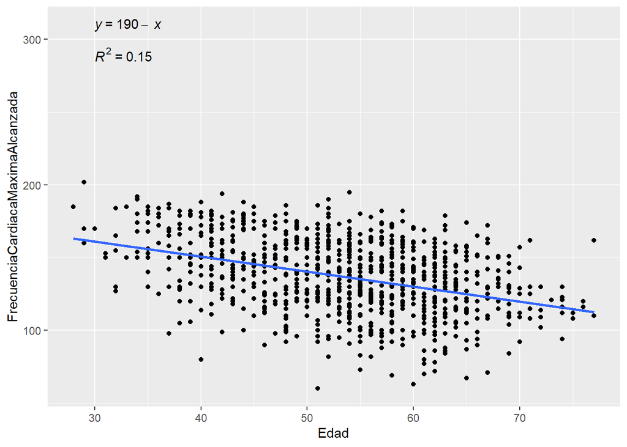

```r
#Scatterplot edad vs frecuencia
ggplot(data = BC, aes(x = Edad, y = FrecuenciaCardiacaMaximaAlcanzada)) +
  geom_point()+
  stat_regline_equation(label.x=30, label.y=310)+
  geom_smooth(method = "lm", se = FALSE)+
  stat_cor(aes(label=..rr.label..), label.x=30, label.y=290)
```

```r
cor(BC$Edad, BC$FrecuenciaCardiacaMaximaAlcanzada)
```

```
## [1] -0.3820447
```

- Scatterplot

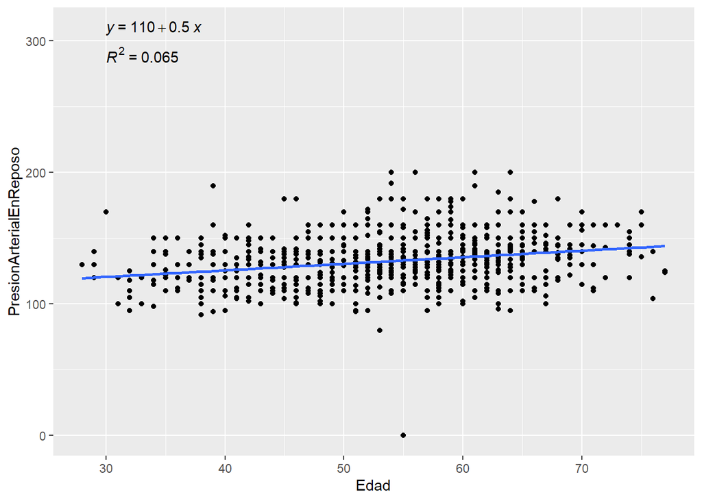

```r
#Scatterplot Edad vs Presion
ggplot(data = BC, aes(x = Edad, y = PresionArterialEnReposo)) +
  geom_point()+
  stat_regline_equation(label.x=30, label.y=310)+
  geom_smooth(method = "lm", se = FALSE)+
  stat_cor(aes(label=..rr.label..), label.x=30, label.y=290)
```

```r
cor(BC$Edad, BC$PresionArterialEnReposo)
```

```
## [1] 0.2543994
```

- Scatterplot:

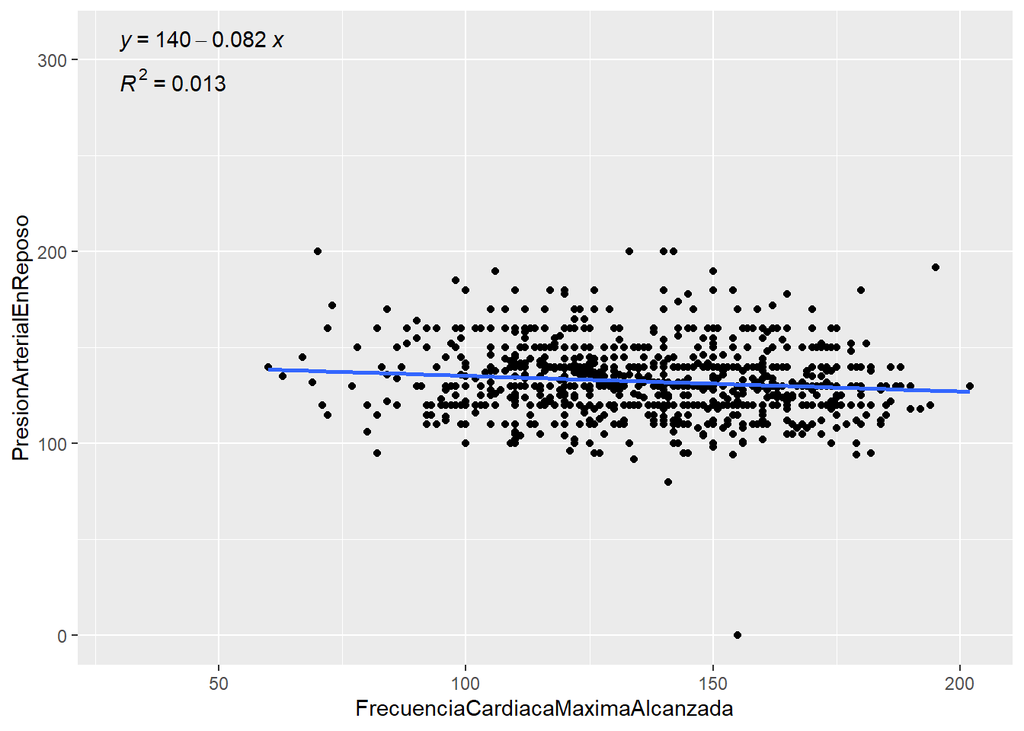

```r
#Scatterplot Frecuencia vs Presion
ggplot(data = BC, aes(x = FrecuenciaCardiacaMaximaAlcanzada, y = PresionArterialEnReposo)) +
  geom_point()+
  stat_regline_equation(label.x=30, label.y=310)+
  geom_smooth(method = "lm", se = FALSE)+
  stat_cor(aes(label=..rr.label..), label.x=30, label.y=290)
```

## Análisis Probabilístico

### Probabilidad frecuentista

**Con relación de tipo de dolor de pecho y los resultados del electro cardiograma. Cual es la probabilidad de que:**

- Al escoger aleatoriamente, el paciente tenga el dolor TA.
- Al escoger aleatoriamente, el paciente tenga el dolor ATA y su electrograma sea normal.
- Al escoger aleatoriamente, el paciente tenga el dolor NP o su electrogama indique STD.
- Al escoger aleatoriamente, el paciente no tenga el dolor ASY ni su electrograma indique normal.
- Al escoger un apciente con dolor ATA, el paciente tenga en su electrograma LVH.

```r
table(BC$TipoDeDolorDePecho,BC$ResultadosDelElectrocardiogramaEnReposo)
```

```
##
##       LVH Normal  ST
##   ASY 102    284 110
##   ATA  23    123  27
##   NAP  47    123  33
##   TA   16     22   8
```

```r
A = table(BC$TipoDeDolorDePecho,BC$ResultadosDelElectrocardiogramaEnReposo)
ASY = sum(A[1,1],A[1,2],A[1,3])
ATA =sum(A[2,1],A[2,2],A[3,3])
NAP = sum(A[3,1],A[3,2],A[3,3])
TA=sum(A[4,1],A[4,2],A[4,3])
LVH=sum(A[1,1],A[2,1],A[3,1],A[4,1])
Normal=sum(A[1,2],A[2,2],A[3,2],A[4,2])
ST=sum(A[1,3],A[2,3],A[3,3],A[4,3])

Total = sum(A)
```

- Al escoger aleatoriamente, el paciente tenga el dolor TA.

$\ P(TA)$

```r
round((TA/Total)*100, digits = 2)
```

```
## [1] 5.01
```

Existe un 5.01% de que el paciente escogido tenga el dolor TA.

- Al escoger aleatoriamente, el paciente tenga el dolor ATA y su electrograma sea normal.

$\ P(ATA \cap Normal)$

```r
round((A[2,2]/Total)*100, digits = 2)
```

```
## [1] 13.4
```

Existe un 13.4% de probabilidad de que el paciente tenga dolor de pecho tipo ATA y en su electrograma tenga un resultado normal.

- Al escoger aleatoriamente, el paciente tenga el dolor NAP o su electrogama indique ST.

$\ P(NAP \cup ST) = P(NAP) + P(ST) - P(NAP \cap ST )$

```r
round((NAP/Total + ST/Total- A[3,3]/Total)*100, digits = 2)
```

```
## [1] 37.91
```

Existe un 37% de que el paciente tenga dolor de pecho tipo NAP o su electrograma presente ST

- Al escoger aleatoriamente, el paciente no tenga el dolor ASY ni su electrograma indique normal.

```r
round((1 - ((ASY/Total) + (Normal/Total) -  (A[1,2]/Total)))*100, digits = 2)
```

```
## [1] 16.78
```

Existe la posibilidad de que el paciente no tenga ni el dolor ASY ni en su electrograma indique resultados normales.

- Al escoger un paciente con dolor ATA, el paciente tenga en su electrograma LVH.

$\ P(LVH/ATA) = P(LVH \cap ATA)/P(ATA)$

```r
round(((A[2,1]/Total)/(ATA/Total))*100, digits = 2)
```

```
## [1] 12.85
```

**Con relación a la edad y los tipos de dolor. Cual es la probabilidad de que:**

- Si se escoge aleatoriamente, El paciente tenga 50 años y no tenga enfermedad cardiaca:
- Si el paciente tiene 60 años, A cual de las opciones(Con Enfermedad y sin enferemdad) tiene mayor probabilidad de pertenecer.
- Si el paciente tiene enferemdad cardiaca, ¿cual es la posibilidad de que tenga 60 años?
- Si se escoge aleatoriamente, Cual es la probabilidad de que el paciente tenga 71 años y tenga enfermedad o tenga 30 años y no tenga la enfermedad

```r
B = table(cut(BC$Edad, breaks = 7),BC$EnfermedadCardiaca)
B
```

```
##
##             0   1
##   (28,35]  22  10
##   (35,42]  72  31
##   (42,49]  86  70
##   (49,56] 124 135
##   (56,63]  68 175
##   (63,70]  30  71
##   (70,77]   8  16
```

```r
Desde28_35 = sum(B[1,1],B[1,2])
Desde35_42 = sum(B[2,1],B[2,2])
Desde42_49 = sum(B[3,1],B[3,2])
Desde49_56 = sum(B[4,1],B[4,2])
Desde56_63 = sum(B[5,1],B[5,2])
Desde63_70 = sum(B[6,1],B[6,2])
Desde70_77 = sum(B[7,1],B[7,2])

SiEnfermedad = sum(B[1,1],B[2,1],B[3,1],B[4,1],B[5,1],B[6,1],B[7,1])
NoEnfermedad = sum(B[1,2],B[2,2],B[3,2],B[4,2],B[5,2],B[6,2],B[7,2])
```

- Si se escoge aleatoriamente, El paciente tenga 50 años y si tenga enfermedad cardiaca:

$P(E50 \cap Y)$

```r
round((B[4,2]/Total)*100, digits = 2)
```

```
## [1] 14.71
```

Existe el 14% de probabilidad de que el paciente tenga 50 años y tenga la enferemdad cardiaca.

- Si el paciente tiene 60 años, A cual de las opciones( sin enferemdad y Con Enfermedad ) tiene mayor probabilidad de pertenecer.

$\ P(N/E60) = P(N \cap E60)/P(E60)$

$\ P(Y/E60) = P(Y \cap E60)/P(E60)$

```r
round((B[5,1]/Desde56_63)*100, digits = 2)
```

```
## [1] 27.98
```

```r
round((B[5,2]/Desde56_63)*100, digits = 2)
```

```
## [1] 72.02
```

Si el paciente tiene 60 años tiene más posibilidad de tener la enfermedad en un 72.02%. Mientras la probabilidad de no tener solo es de 27.98%.

- Si el paciente tiene enferemdad cardiaca, ¿cual es la posibilidad de que tenga 60 años?

$\ P(E60/Y) = P(E60 \cap Y)/P(Y)$

```r
round((B[5,2]/SiEnfermedad)*100, digits = 2)
```

```
## [1] 42.68
```

- Si se escoge aleatoriamente, Cual es la probabilidad de que el paciente tenga 71 años y tenga enfermedad o tenga 30 años y no tenga la enfermedad

$\ P(P1 \cup P2) = P(E71\cap Y) +P(30\cap N )$

```r
round(((B[7,2]/ Total)+(B[1,1]/ Total) )*100, digits = 2)
```

```
## [1] 4.14
```

Existe la probabilidad de 4.14% de que el paciente tenga 71 años y tenga enferemdad o tenga 30 años y no tenga la enfermedad cardiaca

- Fitting para Frecuencia Máxima Alcanzada

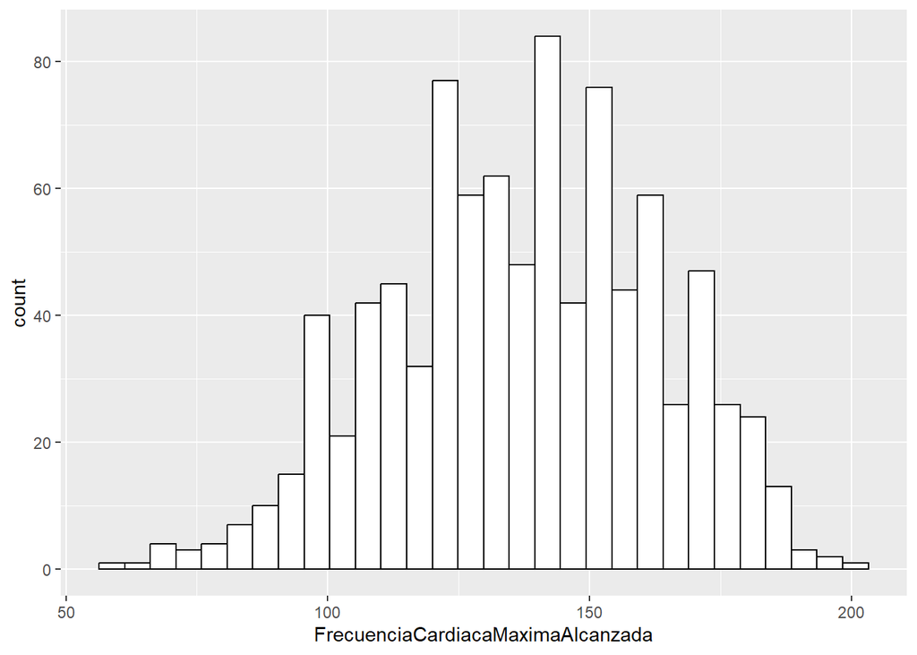

```r
######### Fit a distribution Weibul #####

ggplot(BC, aes(x=FrecuenciaCardiacaMaximaAlcanzada)) +
  geom_histogram(color="black", fill="white")
```

```r
fw <- fitdist(BC$FrecuenciaCardiacaMaximaAlcanzada, "weibull")
fg <- fitdist(BC$FrecuenciaCardiacaMaximaAlcanzada, "gamma")
fln <- fitdist(BC$FrecuenciaCardiacaMaximaAlcanzada, "lnorm")

par(mfrow = c(2, 2))
plot.legend <- c("Weibull", "lognormal", "gamma")
denscomp(list(fw, fln, fg), legendtext = plot.legend)
qqcomp(list(fw, fln, fg), legendtext = plot.legend)

summary(fw)
```

```
## Fitting of the distribution ' weibull ' by maximum likelihood
## Parameters :
##         estimate Std. Error
## shape   6.117584  0.1568450
## scale 147.293190  0.8387508
## Loglikelihood:  -4272.353   AIC:  8548.706   BIC:  8558.35
## Correlation matrix:
##           shape     scale
## shape 1.0000000 0.3200356
## scale 0.3200356 1.0000000
```

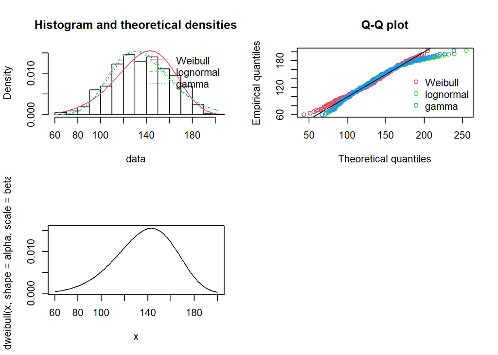

```r
alpha = 6.117584
beta = 147.293190

curve(dweibull(x, shape=alpha, scale = beta), from=60, to=200)
```

- Usando los gráficos anteriores y las siguientes funciones, buscamos determinar cuál es la probabilidad de que un paciente tenga menos de 100 de Frecuencia Cardiaca Máxima Alcanzada:

```r
pweibull(100,shape=alpha,scale=beta)*100
```

```
## [1] 8.932412
```

- Podemos comprobar que nuestra aproximación probabilística es correcta porque nos da un resultado similar al real.

```r
df1 <- BC %>% filter(FrecuenciaCardiacaMaximaAlcanzada<=100)
(nrow(df1)/nrow(BC))*100
```

```
## [1] 9.259259
```

- Fitting para Presion Arterial en Reposo

```r
library(sf)
```

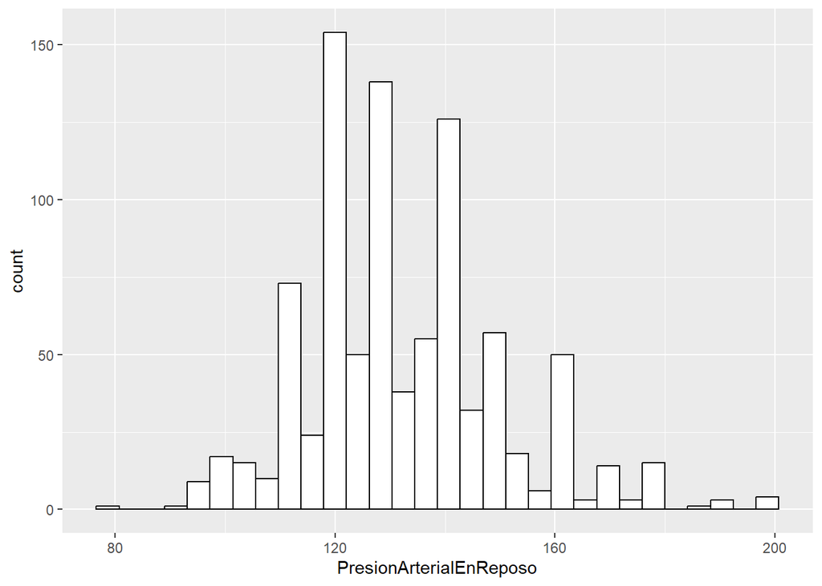

```r
#Hacemos filtros de las observaciones
df_p <- BC %>% filter(PresionArterialEnReposo>50)
ggplot(df_p, aes(x=PresionArterialEnReposo)) +
  geom_histogram(color="black", fill="white")
```

```r
#Guardamos los filtros
fw <- fitdist(df_p$PresionArterialEnReposo, "weibull")
fg <- fitdist(df_p$PresionArterialEnReposo, "gamma")
fln <- fitdist(df_p$PresionArterialEnReposo, "lnorm")

par(mfrow = c(2, 2))

plot.legend <- c("Weibull", "lognormal", "gamma")
denscomp(list(fw, fln, fg), legendtext = plot.legend)
qqcomp(list(fw, fln, fg), legendtext = plot.legend)

summary(fln)
```

```
## Fitting of the distribution ' lnorm ' by maximum likelihood
## Parameters :
##          estimate  Std. Error
## meanlog 4.8779014 0.004412660
## sdlog   0.1336242 0.003119436
## Loglikelihood:  -3928.535   AIC:  7861.069   BIC:  7870.711
## Correlation matrix:
##         meanlog sdlog
## meanlog       1     0
## sdlog         0     1
```

```r
# Obtenemos nuestros parámetros para poder graficar
meanlog_= 4.8779014
sdlog_ = 0.1336242
```

[figure not shown]

- Buscamos la probabilidad que un paciente tenga Presion Arterial en Reposo menor a 170:

```r
plnorm(170, meanlog = meanlog_, sdlog = sdlog_, lower.tail = TRUE, log.p = FALSE)
```

```
## [1] 0.9731977
```

- Podemos comprobar que la aproximación realizada es correcta, ya que dan resultados similares a los reales.

```r
df2 <- df_p %>% filter(PresionArterialEnReposo<=170)
(nrow(df2)/nrow(df_p))
```

```
## [1] 0.9716467
```

DISTRIBUCION BINOMIAL

En siguiente modelo tiene como objetivo determinar la probabilidad que 6 de una muestra de 80 tengan el dolor de pecho tipo TA.

El modelo presenta distribución binomial porque presenta elementos con reposición, ademas la probabilidad es la misma para todas.

```r
table(BC$TipoDeDolorDePecho)
```

```
##
## ASY ATA NAP  TA
## 496 173 203  46
```

Valor esperado: 4 personas Se espera que 4 personas tengan el dolor de pecho tipo TA.

X: 6 personas n: muestra de la población obtenida 80 personas de 918 p:probabilidad de éxito 46/918

x tiene una probabilidad Binomial con 80 ensayos y 0.050109 de probabilidad Sea X ~ B(n=80; p=46/918)

```r
dbinom(6,80,46/918)
```

```
## [1] 0.1059735
```

CONCLUSION:

La probabilidad que 6 personas tengan el tipo de dolor de pecho TA es de 0.11

## Referencias bibliograficas:

[Vega Abascal, J., Guimará Mosqueda, M., & Vega Abascal, L. (2011). Riesgo cardiovascular, una herramienta útil para la prevención de las enfermedades cardiovasculares. Revista Cubana de Medicina General Integral, 27(1). http://scielo.sld.cu/scielo.php?pid=S0864-21252011000100010&script=sci_arttext&tlng=en ]

[Baena Díez, J. M., del Val García, J. L., Tomàs Pelegrina, J., Martínez Martínez, J. LMartín Peñacoba, R., González Tejón, I., Raidó Quintana, E. M., Pomares Sajkiewicz, M., Altés Boronat, A., Álvarez Pérez, B., Piñol Forcadell, P., Rovira España, M., & Oller Colom, M. (2005). Epidemiología de las enfermedades cardiovasculares y factores de riesgo en atención primaria. Revista Española de Cardiología, 58(4), 367–373. https://doi.org/10.1157/13073893 ]

[Pérez Fernández, Y., & Soto García, A. (2017, junio). FACTORES DE RIESGO DE LAS ENFERMEDADES CARDIOVASCULARES. UNIVERSIDAD COMPLUTENSE DE MADRID. http://147.96.70.122/Web/TFG/TFG/Memoria/ANA%20SOTO%20GARCIA.pdf ]

Actualización de estadísticas sobre enfermedades cardíacas y ataques o derrames cerebrales, año 2022. (2022). American Heart Association, 43(7), 545-549. https://www.heart.org/-/media/PHD-Files-2/Science-News/2/2022-Heart-and-Stroke-Stat-Update/Translated-Materials/2022-Stat-Update-at-a-Glance-Spanish.pdf

[Equipo NO-KO de Federación Aturiana de Empresarios (2022)FRECUENCIA CARDÍACA MÁXIMA: ¿QUÉ ES? ¿COMO CALCULARLA? http://fadesaludable.es/2017/02/23/frecuencia-cardiaca-maxima-que-es-como-calcularla/]